# Exploratory Data Analysis and Correlation Analysis of Heart Disease Dataset

CONFIDENCE

2024-08-19

Introduction

This project works on exploratory data analysis on heart disease data,including summary statistic,correlation analysis,and interactive visualization.

Data Loading The data set contain various features related to heart disease

```r
#Install the necessary libraries
library(tidyverse)
```

```r
library(reactable)
library(corrplot)
getwd()
```

```
## [1] "C:/Users/user/Documents/heart/heart/Dataset,codeandReport"
```

```r
setwd("C:/Users/user/Documents/heart/heart/Dataset,codeandReport")
# Read in the data set
Heart_data <- read.csv("C:/Users/user/Documents/heart/heart/Dataset,codeandReport/heart.csv")
#Display the first few rows of the data
head(Heart_data)
```

```
##   age sex cp trtbps chol fbs restecg thalachh exng oldpeak slp caa thall output
## 1  63   1  3    145  233   1       0      150    0     2.3   0   0     1      1
## 2  37   1  2    130  250   0       1      187    0     3.5   0   0     2      1
## 3  41   0  1    130  204   0       0      172    0     1.4   2   0     2      1
## 4  56   1  1    120  236   0       1      178    0     0.8   2   0     2      1
## 5  57   0  0    120  354   0       1      163    1     0.6   2   0     2      1
## 6  57   1  0    140  192   0       1      148    0     0.4   1   0     1      1
```

Data Exploration This process involve knowing the structure of the data and check for missing value

```r
str(Heart_data)
```

```
## 'data.frame':    303 obs. of  14 variables:
##  $ age     : int  63 37 41 56 57 57 56 44 52 57 ...
##  $ sex     : int  1 1 0 1 0 1 0 1 1 1 ...
##  $ cp      : int  3 2 1 1 0 0 1 1 2 2 ...
##  $ trtbps  : int  145 130 130 120 120 140 140 120 172 150 ...
##  $ chol    : int  233 250 204 236 354 192 294 263 199 168 ...
##  $ fbs     : int  1 0 0 0 0 0 0 0 1 0 ...
##  $ restecg : int  0 1 0 1 1 1 0 1 1 1 ...
##  $ thalachh: int  150 187 172 178 163 148 153 173 162 174 ...
##  $ exng    : int  0 0 0 0 1 0 0 0 0 0 ...
##  $ oldpeak : num  2.3 3.5 1.4 0.8 0.6 0.4 1.3 0 0.5 1.6 ...
##  $ slp     : int  0 0 2 2 2 1 1 2 2 2 ...
##  $ caa     : int  0 0 0 0 0 0 0 0 0 0 ...
##  $ thall   : int  1 2 2 2 2 1 2 3 3 2 ...
##  $ output  : int  1 1 1 1 1 1 1 1 1 1 ...
```

```r
#check for missing value
sum(is.na(Heart_data))
```

```
## [1] 0
```

Summary Statistics we calculate summary statistics for the numerical features, grouped by the `output` variable.

```r
# Calculate summary statistics
summary_stats <- Heart_data %>%
  group_by(output) %>%
  summarise(across(everything(), list(mean = ~ mean(. , na.rm = TRUE),
                                      sd = ~ sd(. , na.rm = TRUE),
                                      min = ~ min(. , na.rm = TRUE),
                                      max = ~ max(. , na.rm = TRUE))))
summary_stats
```

```
## # A tibble: 2 × 53
##   output age_mean age_sd age_min age_max sex_mean sex_sd sex_min sex_max cp_mean
##    <int>    <dbl>  <dbl>   <int>   <int>    <dbl>  <dbl>   <int>   <int>   <dbl>
## 1      0     56.6   7.96      35      77    0.826  0.380       0       1   0.478
## 2      1     52.5   9.55      29      76    0.564  0.497       0       1   1.38
## # ℹ 43 more variables: cp_sd <dbl>, cp_min <int>, cp_max <int>,
## #   trtbps_mean <dbl>, trtbps_sd <dbl>, trtbps_min <int>, trtbps_max <int>,
## #   chol_mean <dbl>, chol_sd <dbl>, chol_min <int>, chol_max <int>,
## #   fbs_mean <dbl>, fbs_sd <dbl>, fbs_min <int>, fbs_max <int>,
## #   restecg_mean <dbl>, restecg_sd <dbl>, restecg_min <int>, restecg_max <int>,
## #   thalachh_mean <dbl>, thalachh_sd <dbl>, thalachh_min <int>,
## #   thalachh_max <int>, exng_mean <dbl>, exng_sd <dbl>, exng_min <int>, …
```

```r
# Convert to a format suitable for reactable
summary_stats_df <- summary_stats %>%
  pivot_longer(cols = -output, names_to = c("variable", ".value"), names_sep = "_")
print(summary_stats_df)
```

```
## # A tibble: 26 × 6
##    output variable    mean     sd   min   max
##     <int> <chr>      <dbl>  <dbl> <dbl> <dbl>
##  1      0 age       56.6    7.96     35  77
##  2      0 sex        0.826  0.380     0   1
##  3      0 cp         0.478  0.906     0   3
##  4      0 trtbps   134.    18.7     100 200
##  5      0 chol     251.    49.5     131 409
##  6      0 fbs        0.159  0.367     0   1
##  7      0 restecg    0.449  0.541     0   2
##  8      0 thalachh 139.    22.6      71 195
##  9      0 exng       0.551  0.499     0   1
## 10      0 oldpeak    1.59   1.30      0   6.2
## # ℹ 16 more rows
```

Correlation Analysis This has to do with correlation matrix for the numeric variable and visualize using a correlation plot.

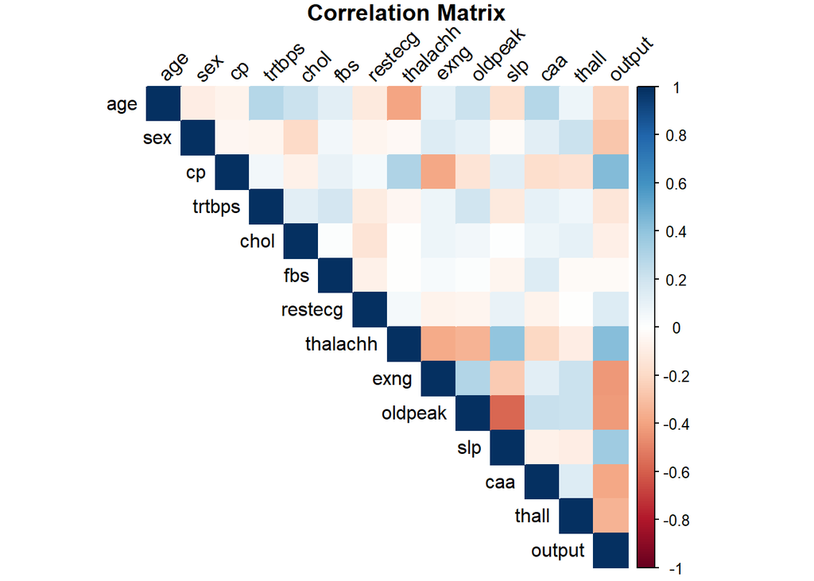

```r
# Select numeric columns and calculate correlation matrix
numeric_data <- Heart_data %>% select(where(is.numeric))
cor_matrix <- round(cor(numeric_data, use = "complete.obs"), 2)

# Create the correlation plot
corrplot(cor_matrix,
         method = "color",
         type = "upper",
         tl.col = "black",
         tl.srt = 45,
         title = "Correlation Matrix",
         mar = c(0, 0, 1, 0))
```

Interactive Tables

Interactive tables using `reactable` enhance data exploration by allowing users to filter, search, and sort data dynamically. I will be creating interactive table for both summart and the correlation matrix

```r
# Create an interactive table for summary statistics
reactable(summary_stats_df,
          columns = list(
            variable = colDef(name = "Features"),
            mean = colDef(name = "Mean Value"),
            sd = colDef(name = "Standard Deviation"),
            min = colDef(name = "Minimum Value"),
            max = colDef(name = "Maximum Value")
          ),
          filterable = TRUE,
          searchable = TRUE,
          defaultPageSize = 10)
```

| output | Features | Mean Value | Standard Deviation | Minimum Value | Maximum Value |
| --- | --- | --- | --- | --- | --- |
| 0 | age | 56.6014492753623 | 7.96208153750117 | 35 | 77 |
| 0 | sex | 0.826086956521739 | 0.380415513861212 | 0 | 1 |
| 0 | cp | 0.478260869565217 | 0.905920440137594 | 0 | 3 |
| 0 | trtbps | 134.398550724638 | 18.7299439615813 | 100 | 200 |
| 0 | chol | 251.086956521739 | 49.4546136040716 | 131 | 409 |
| 0 | fbs | 0.159420289855072 | 0.367401147370237 | 0 | 1 |
| 0 | restecg | 0.449275362318841 | 0.541321224549415 | 0 | 2 |
| 0 | thalachh | 139.101449275362 | 22.5987822987859 | 71 | 195 |
| 0 | exng | 0.550724637681159 | 0.499232458589906 | 0 | 1 |
| 0 | oldpeak | 1.58550724637681 | 1.30033969310537 | 0 | 6.2 |

[output cut: 16 more lines]

```r
print(summary_stats_df)
```

```
## # A tibble: 26 × 6
##    output variable    mean     sd   min   max
##     <int> <chr>      <dbl>  <dbl> <dbl> <dbl>
##  1      0 age       56.6    7.96     35  77
##  2      0 sex        0.826  0.380     0   1
##  3      0 cp         0.478  0.906     0   3
##  4      0 trtbps   134.    18.7     100 200
##  5      0 chol     251.    49.5     131 409
##  6      0 fbs        0.159  0.367     0   1
##  7      0 restecg    0.449  0.541     0   2
##  8      0 thalachh 139.    22.6      71 195
##  9      0 exng       0.551  0.499     0   1
## 10      0 oldpeak    1.59   1.30      0   6.2
## # ℹ 16 more rows
```

```r
# Convert correlation matrix to long format and display as a reactable table
cor_matrix_df <- as.data.frame(as.table(cor_matrix))
reactable(cor_matrix_df,
          columns = list(
            Var1 = colDef(name = "Feature 1"),
            Var2 = colDef(name = "Feature 2"),
            Freq = colDef(name = "Correlation Coefficient")
          ),
          filterable = TRUE,
          searchable = TRUE,
          defaultPageSize = 15)
```

| Feature 1 | Feature 2 | Correlation Coefficient |
| --- | --- | --- |
| age | age | 1 |
| sex | age | -0.1 |
| cp | age | -0.07 |
| trtbps | age | 0.28 |
| chol | age | 0.21 |
| fbs | age | 0.12 |
| restecg | age | -0.12 |
| thalachh | age | -0.4 |
| exng | age | 0.1 |
| oldpeak | age | 0.21 |

[output cut: 186 more lines]

Conclusion

This project leveraged exploratory data analysis to dissect the heart disease dataset, revealing crucial connections among various health metrics. By generating comprehensive summary statistics and visualizing correlations, we highlighted key trends and relationships pertinent to heart disease. The interactive tables offered a user-friendly approach to navigate and interpret the data, enhancing our ability to uncover and understand underlying patterns. These insights not only contribute to a better grasp of cardiovascular health but also set the stage for future analysis and potential interventions.